# Beta diversity ordinations

Nick Youngblut

2016-08-15

# Beta diversity ordinations

## Dataset

First, let’s load some packages including `HTSSIP`.

```r
library(dplyr)
library(ggplot2)
library(HTSSIP)
```

Also let’s get an overview of the phyloseq object that we’re going to use.

```r
physeq_S2D2
```

```
## phyloseq-class experiment-level object
## otu_table()   OTU Table:         [ 10001 taxa and 139 samples ]
## sample_data() Sample Data:       [ 139 samples by 17 sample variables ]
## tax_table()   Taxonomy Table:    [ 10001 taxa by 8 taxonomic ranks ]
## phy_tree()    Phylogenetic Tree: [ 10001 tips and 10000 internal nodes ]
```

## Parsing the dataset

See HTSSIP introduction vignette for a description on why dataset parsing is needed.

Let’s the parameters for parsing the dataset into individual treatment-control comparisons.

```r
params = get_treatment_params(physeq_S2D2, c('Substrate', 'Day'))
params
```

```
##   Substrate Day
## 1   12C-Con  14
## 2   13C-Cel   3
## 3   13C-Cel  14
## 4   13C-Glu  14
## 5   12C-Con   3
## 6   13C-Glu   3
```

We just need the parameters for each treatment, so let’s filter out the controls. In this case, the controls are all ‘12C-Con’.

```r
params = dplyr::filter(params, Substrate!='12C-Con')
params
```

```
##   Substrate Day
## 1   13C-Cel   3
## 2   13C-Cel  14
## 3   13C-Glu  14
## 4   13C-Glu   3
```

Now, we will use an expression that will subset the phyloseq object into the comparisons that we want to make.

`ex` is the expression that will be used for pruning the phyloseq object

```r
ex = "(Substrate=='12C-Con' & Day=='${Day}') | (Substrate=='${Substrate}' & Day == '${Day}')"
physeq_S2D2_l = phyloseq_subset(physeq_S2D2, params, ex)
physeq_S2D2_l
```

```
## $`(Substrate=='12C-Con' & Day=='3') | (Substrate=='13C-Cel' & Day == '3')`
## phyloseq-class experiment-level object
## otu_table()   OTU Table:         [ 10001 taxa and 46 samples ]
## sample_data() Sample Data:       [ 46 samples by 17 sample variables ]
## tax_table()   Taxonomy Table:    [ 10001 taxa by 8 taxonomic ranks ]
## phy_tree()    Phylogenetic Tree: [ 10001 tips and 10000 internal nodes ]
##
## $`(Substrate=='12C-Con' & Day=='14') | (Substrate=='13C-Cel' & Day == '14')`
## phyloseq-class experiment-level object
## otu_table()   OTU Table:         [ 10001 taxa and 46 samples ]
## sample_data() Sample Data:       [ 46 samples by 17 sample variables ]
## tax_table()   Taxonomy Table:    [ 10001 taxa by 8 taxonomic ranks ]
## phy_tree()    Phylogenetic Tree: [ 10001 tips and 10000 internal nodes ]
##
## $`(Substrate=='12C-Con' & Day=='14') | (Substrate=='13C-Glu' & Day == '14')`
## phyloseq-class experiment-level object
## otu_table()   OTU Table:         [ 10001 taxa and 47 samples ]
## sample_data() Sample Data:       [ 47 samples by 17 sample variables ]
## tax_table()   Taxonomy Table:    [ 10001 taxa by 8 taxonomic ranks ]
## phy_tree()    Phylogenetic Tree: [ 10001 tips and 10000 internal nodes ]
##
## $`(Substrate=='12C-Con' & Day=='3') | (Substrate=='13C-Glu' & Day == '3')`
## phyloseq-class experiment-level object
## otu_table()   OTU Table:         [ 10001 taxa and 46 samples ]
## sample_data() Sample Data:       [ 46 samples by 17 sample variables ]
## tax_table()   Taxonomy Table:    [ 10001 taxa by 8 taxonomic ranks ]
## phy_tree()    Phylogenetic Tree: [ 10001 tips and 10000 internal nodes ]
```

## Calculating ordinations

Now, let’s actually make ordinations of each treatment compared to the control. This will return a `data.frame` object for plotting.

```r
physeq_S2D2_l_df = SIP_betaDiv_ord(physeq_S2D2_l)
```

```
## *** Solution reached
## *** Solution reached
## *** Solution reached
## *** Solution reached
```

```r
physeq_S2D2_l_df %>% head(n=3)
```

```
##                                                           phyloseq_subset
## 1 (Substrate=='12C-Con' & Day=='3') | (Substrate=='13C-Cel' & Day == '3')
## 2 (Substrate=='12C-Con' & Day=='3') | (Substrate=='13C-Cel' & Day == '3')
## 3 (Substrate=='12C-Con' & Day=='3') | (Substrate=='13C-Cel' & Day == '3')
##        NMDS1        NMDS2          X.Sample primer_number fwd_barcode
## 1 -0.1597160 -0.031606482 13C-Cel.D3.R1_F21             7    GGATATCT
## 2 -0.2082193 -0.090323655 13C-Cel.D3.R1_F20             6    CGTGAGTG
## 3 -0.0188402 -0.006268322 13C-Cel.D3.R1_F15             1    ATCGTACG
##   rev_barcode Substrate Day Microcosm_replicate Fraction Buoyant_density
## 1    CGAGAGTT   13C-Cel   3                   1       21        1.705640
## 2    CGAGAGTT   13C-Cel   3                   1       20        1.706186
## 3    CGAGAGTT   13C-Cel   3                   1       15        1.725310
##   Sample_type
## 1     unknown
## 2     unknown
## 3     unknown
##                                                                                   library
## 1 /var/seq_data/fullCyc/MiSeq_16SrRNA/515f-806r/lib1-7rs/../150721_lib4/run1/metadata.txt
## 2 /var/seq_data/fullCyc/MiSeq_16SrRNA/515f-806r/lib1-7rs/../150721_lib4/run1/metadata.txt
## 3 /var/seq_data/fullCyc/MiSeq_16SrRNA/515f-806r/lib1-7rs/../150721_lib4/run1/metadata.txt
##   Exp_type Sample_location Sample_date Sample_treatment
## 1      SIP              NA          NA               NA
## 2      SIP              NA          NA               NA
## 3      SIP              NA          NA               NA
##   Sample_subtreatment core_dataset
## 1                  NA         TRUE
## 2                  NA         TRUE
## 3                  NA         TRUE
```

Each specific phyloseq subset (treatment-control comparison) is delimited with the “phyloseq_subset” column.

```r
physeq_S2D2_l_df %>% .$phyloseq_subset %>% unique
```

```
## [1] (Substrate=='12C-Con' & Day=='3') | (Substrate=='13C-Cel' & Day == '3')
## [2] (Substrate=='12C-Con' & Day=='14') | (Substrate=='13C-Cel' & Day == '14')
## [3] (Substrate=='12C-Con' & Day=='14') | (Substrate=='13C-Glu' & Day == '14')
## [4] (Substrate=='12C-Con' & Day=='3') | (Substrate=='13C-Glu' & Day == '3')
## 4 Levels: (Substrate=='12C-Con' & Day=='3') | (Substrate=='13C-Cel' & Day == '3') ...
```

For clarity, I’m going edit these long strings to make them more readable.

```r
physeq_S2D2_l_df = physeq_S2D2_l_df %>%
  dplyr::mutate(phyloseq_subset = gsub(' \\| ', '\n', phyloseq_subset))
physeq_S2D2_l_df %>% .$phyloseq_subset %>% unique
```

```
## [1] "(Substrate=='12C-Con' & Day=='3')\n(Substrate=='13C-Cel' & Day == '3')"
## [2] "(Substrate=='12C-Con' & Day=='14')\n(Substrate=='13C-Cel' & Day == '14')"
## [3] "(Substrate=='12C-Con' & Day=='14')\n(Substrate=='13C-Glu' & Day == '14')"
## [4] "(Substrate=='12C-Con' & Day=='3')\n(Substrate=='13C-Glu' & Day == '3')"
```

Let’s plot the data!

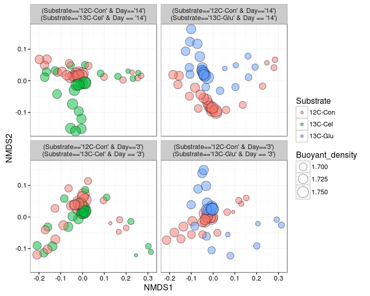

```r
phyloseq_ord_plot(physeq_S2D2_l_df)
```

As you can see, the ‘heavy’ gradient fraction communities for the labeled-treatments tend to diverge from the unlabeled gradient fraction communities, but the amount of divergence in dependent on substrate and time point.